# Nominal Predictors in Multivariate Linear Regression

László Kovács

30/01/2026

## 1. Used Car Dataset

In this section, we work with the cars.xlsx file. The dataset contains information on 100 used cars and includes the following eight variables:

- **Price**: Purchase price (HUF)
- **Age**: Age of the car in years
- **Mileage**: Mileage in km
- **Weight**: Vehicle weight in kilograms
- **Cylinder**: Engine cylinder capacity in cubic centimeters (cc)
- **Power**: Engine power in kW
- **Type**: Text-based assessment of the vehicle’s condition
- **Fuel**: Fuel type (petrol or diesel)

The dataset is stored in Excel format (*.xlsx*), not as a CSV file. Excel files can be imported into R as a `data.frame` using the `readxl` package.

First, load the package:

```r
library(readxl)
```

Next, we use the `read_excel()` function. If the file contains a single worksheet and the data start in cell *A1*, the function will correctly import the data without requiring any additional arguments:

```r
used_cars <- read_excel("cars.xlsx")
str(used_cars)
```

```
## tibble [100 × 8] (S3: tbl_df/tbl/data.frame)
##  $ Price   : num [1:100] 599000 799999 950000 999990 1190000 ...
##  $ Age     : num [1:100] 13 13 12 12 14 12 13 13 9 10 ...
##  $ Mileage : num [1:100] 320000 202000 326600 193000 212311 ...
##  $ Weight  : num [1:100] 1805 1805 1740 1880 1760 ...
##  $ Cylinder: num [1:100] 1686 1364 1598 1910 1796 ...
##  $ Power   : num [1:100] 80 90 105 120 125 105 90 105 90 116 ...
##  $ Type    : chr [1:100] "Normal" "Normal" "Normal" "Normal" ...
##  $ Fuel    : chr [1:100] "Diesel" "Petrol" "Petrol" "Diesel" ...
```

Everything looks fine: all 100 observations and all 8 variables are present. Since **Type** and **Fuel** are categorical variables stored as text, we convert them to the `factor` type:

```r
used_cars$Type <- as.factor(used_cars$Type)
used_cars$Fuel <- as.factor(used_cars$Fuel)

str(used_cars)
```

```
## tibble [100 × 8] (S3: tbl_df/tbl/data.frame)
##  $ Price   : num [1:100] 599000 799999 950000 999990 1190000 ...
##  $ Age     : num [1:100] 13 13 12 12 14 12 13 13 9 10 ...
##  $ Mileage : num [1:100] 320000 202000 326600 193000 212311 ...
##  $ Weight  : num [1:100] 1805 1805 1740 1880 1760 ...
##  $ Cylinder: num [1:100] 1686 1364 1598 1910 1796 ...
##  $ Power   : num [1:100] 80 90 105 120 125 105 90 105 90 116 ...
##  $ Type    : Factor w/ 5 levels "Excellent","Like New",..: 3 3 3 3 3 3 1 4 3 1 ...
##  $ Fuel    : Factor w/ 2 levels "Diesel","Petrol": 1 2 2 1 2 2 2 2 1 2 ...
```

Now the dataset is ready for analysis.

Let us also check the possible categories of the **Type** variable:

```r
levels(used_cars$Type)
```

```
## [1] "Excellent" "Like New"  "Normal"    "Spared"    "Undamaged"
```

## 2. Dummy Variables in R

When we include a nominal (categorical) variable as an explanatory variable in an OLS regression — such as **Type** or **Fuel** — R automatically applies *dummy coding*.

The idea is the following: one category of the nominal variable is chosen as the **reference category** and is omitted from the model. For each of the remaining categories, R creates a separate binary (dummy) variable that takes the value 1 if the observation belongs to that category and 0 otherwise.

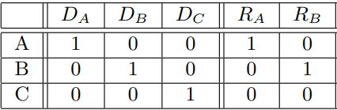

In the table above, $D_A$ and $D_B$ represent the dummy variables included in the regression, while category $C$ is the reference category. The reference category must be omitted because if $D_A = 0$ and $D_B = 0$, then $D_C = 1$ automatically. Including all three would create perfect linear dependence among the regressors.

This problem is known as **perfect multicollinearity**. In such cases, the matrix $(X^TX)$ cannot be inverted in the OLS estimator

$$\hat{\beta} =
(X^TX)^{-1}X^Ty,$$

which makes estimation of $\beta$ impossible.

With this in mind, let us estimate an OLS regression where the purchase price is explained by all other variables in the dataset, including the two categorical ones:

```r
cars_model <- lm(Price ~ ., data = used_cars)
summary(cars_model)
```

```
##
## Call:
## lm(formula = Price ~ ., data = used_cars)
##
## Residuals:
##     Min      1Q  Median      3Q     Max
## -523618  -95376   12468  113660  325509
##
## Coefficients:
##                 Estimate Std. Error t value Pr(>|t|)
## (Intercept)    2.286e+06  6.296e+05   3.631 0.000472 ***
## Age           -7.273e+04  9.353e+03  -7.776 1.25e-11 ***
## Mileage       -2.454e+00  3.618e-01  -6.784 1.25e-09 ***
## Weight        -1.644e+02  3.718e+02  -0.442 0.659362
## Cylinder       4.202e+01  1.606e+02   0.262 0.794182
## Power          4.647e+03  1.601e+03   2.903 0.004658 **
## TypeLike New   2.266e+05  1.144e+05   1.980 0.050737 .
## TypeNormal    -1.192e+05  4.947e+04  -2.411 0.017983 *
## TypeSpared     4.186e+04  5.081e+04   0.824 0.412253
## TypeUndamaged -9.419e+03  1.127e+05  -0.084 0.933609
## FuelPetrol     3.763e+04  4.666e+04   0.806 0.422134
## ---
## Signif. codes:  0 '***' 0.001 '**' 0.01 '*' 0.05 '.' 0.1 ' ' 1
##
## Residual standard error: 178400 on 89 degrees of freedom
## Multiple R-squared:  0.7279, Adjusted R-squared:  0.6974
## F-statistic: 23.81 on 10 and 89 DF,  p-value: < 2.2e-16
```

We can see that for **Fuel**, the omitted reference category is *Diesel*, while for **Type**, the reference category is *Excellent*.

All dummy coefficients must therefore be interpreted **relative to the reference category**:

- $\beta_{Petrol} = +37{,}630$: holding all other variables constant, a petrol car is expected to be about 37,630 HUF more expensive than a diesel car.
- $\beta_{Normal} = -119{,}200$: holding all other variables constant, a car in normal condition is expected to be about 119,200 HUF cheaper than a car in excellent condition.

### 2.1 Changing the Reference Category

In the previous model, using *Excellent* as the reference category may not be the most intuitive choice. A more natural baseline would be *Normal* condition. In R, the reference category of a factor can be changed using the `relevel()` function.

By default, the reference category is the first level in alphabetical order:

```r
levels(used_cars$Type)
```

```
## [1] "Excellent" "Like New"  "Normal"    "Spared"    "Undamaged"
```

We override this by setting *Normal* as the reference category:

```r
used_cars$Type <- relevel(used_cars$Type, ref = "Normal")
levels(used_cars$Type)
```

```
## [1] "Normal"    "Excellent" "Like New"  "Spared"    "Undamaged"
```

Now we re-estimate the regression model:

```r
cars_model <- lm(Price ~ ., data = used_cars)
summary(cars_model)
```

```
##
## Call:
## lm(formula = Price ~ ., data = used_cars)
##
## Residuals:
##     Min      1Q  Median      3Q     Max
## -523618  -95376   12468  113660  325509
##
## Coefficients:
##                 Estimate Std. Error t value Pr(>|t|)
## (Intercept)    2.166e+06  6.227e+05   3.479 0.000781 ***
## Age           -7.273e+04  9.353e+03  -7.776 1.25e-11 ***
## Mileage       -2.454e+00  3.618e-01  -6.784 1.25e-09 ***
## Weight        -1.644e+02  3.718e+02  -0.442 0.659362
## Cylinder       4.202e+01  1.606e+02   0.262 0.794182
## Power          4.647e+03  1.601e+03   2.903 0.004658 **
## TypeExcellent  1.192e+05  4.947e+04   2.411 0.017983 *
## TypeLike New   3.458e+05  1.147e+05   3.015 0.003353 **
## TypeSpared     1.611e+05  4.349e+04   3.704 0.000367 ***
## TypeUndamaged  1.098e+05  1.091e+05   1.007 0.316676
## FuelPetrol     3.763e+04  4.666e+04   0.806 0.422134
## ---
## Signif. codes:  0 '***' 0.001 '**' 0.01 '*' 0.05 '.' 0.1 ' ' 1
##
## Residual standard error: 178400 on 89 degrees of freedom
## Multiple R-squared:  0.7279, Adjusted R-squared:  0.6974
## F-statistic: 23.81 on 10 and 89 DF,  p-value: < 2.2e-16
```

The interpretation now becomes more intuitive: holding all other variables constant, a car in excellent condition is expected to cost $\beta_{Excellent} = +119{,}200$ HUF more than a car in normal condition.

Note that the magnitude of the effect is exactly the same as before; only the sign has changed. This is because we simply changed the reference category.

### 2.2 Visualizing the Interpretation of Dummy Variables

To better understand how dummy variables work in an OLS regression, let us visualize the estimated relationships using the `sjPlot` package.

```r
install.packages("sjPlot")
library(sjPlot)
```

First, we plot the **predicted** purchase price ($\hat{y}$) as a function of the car’s age (**Age**):

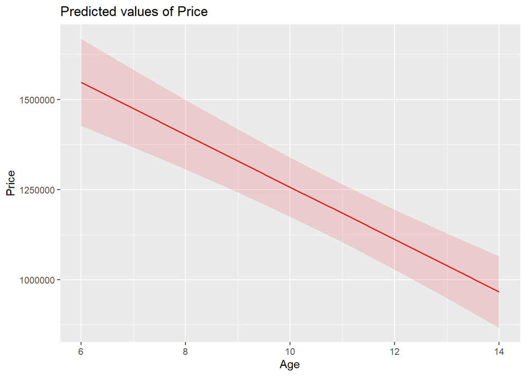

```r
plot_model(cars_model, type = "pred", terms = c("Age"))
```

Next, we include the **Type** variable in the plot:

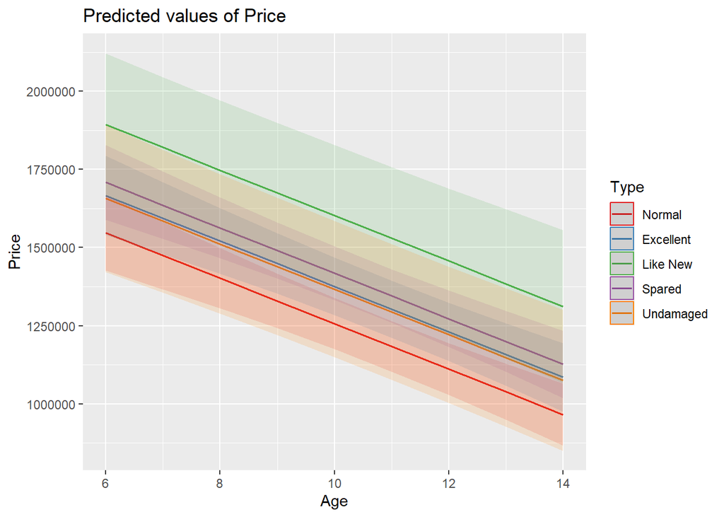

```r
plot_model(cars_model, type = "pred", terms = c("Age", "Type"))
```

This clearly shows that **dummy variables shift the intercept of the regression line**. The slope with respect to age is the same for all condition categories: as the car gets one year older, its expected price decreases by about 72,730 HUF regardless of condition. What differs across categories is the baseline price level.

The intercept $\beta_0$ corresponds to the predicted outcome for the **reference category**, since all dummy variables take the value zero at that point. (Of course, this also implicitly assumes that all other explanatory variables are zero.)

## 3. Exporting R Output Tables to Excel

For the group assignment, it is often useful to export R output tables to Excel so they can be easily formatted and inserted into a written report. This can be done conveniently using the `write_xlsx()` function from the `writexl` package.

First, install and load the package:

```r
install.packages("writexl")
library(writexl)
```

The `write_xlsx()` function can export `data.frame` objects directly to Excel. For example, to export the coefficient table of a regression model, we first save it as a `data.frame`:

```r
Betas <- as.data.frame(summary(cars_model)$coefficients)
```

We can then write it to an Excel file. Note that the file will be saved in the current **working directory**:

```r
write_xlsx(Betas, "Betas_Car.xlsx")
```

You may notice that the variable names are missing from the Excel file. This happens because they are stored as row names rather than as a separate column. We can fix this by explicitly adding them:

```r
Betas$Variable <- row.names(Betas)
write_xlsx(Betas, "Betas_Car.xlsx")
```

The same approach can be used for other output tables, such as descriptive statistics:

```r
library(psych)

DescStat <- as.data.frame(describe(used_cars))
DescStat$VariableName <- row.names(DescStat)

write_xlsx(DescStat, "DescStat_Car.xlsx")
```